# Using Models 2

## Q1 (4 pts.): Re-create the conditional boxplot of penguin body mass conditioned on sex and species. Include your boxplot as a figure in your report.

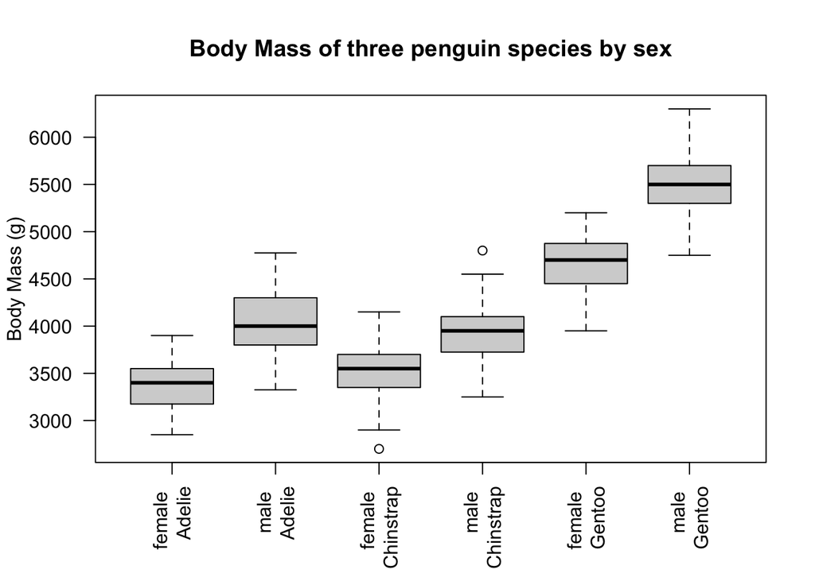

```r
boxplot(body_mass_g ~ sex+species, data = penguins, main= "Body Mass of three penguin species by sex", ylab="Body Mass (g)", las=2, xlab=" ", names=c("female \n Adelie", "male \n Adelie", "female \n Chinstrap", "male \n Chinstrap", "female \n Gentoo", "male \n Gentoo"))
```

## Q3 (2 pts.): Do you think adding sex to a model that already includes species will improve the model fit?

Yes, I think it will help explain the subtle differences, especially within Gentoo.

## Q4 (2 pts.): Show the R-code you used to build fit_both

```r
fit_both=lm(body_mass_g ~ sex * species, data = penguins)
summary(fit_both)
```

```
##
## Call:
## lm(formula = body_mass_g ~ sex * species, data = penguins)
##
## Residuals:
##     Min      1Q  Median      3Q     Max
## -827.21 -213.97   11.03  206.51  861.03
##
## Coefficients:
##                          Estimate Std. Error t value Pr(>|t|)
## (Intercept)               3368.84      36.21  93.030  < 2e-16 ***
## sexmale                    674.66      51.21  13.174  < 2e-16 ***
## speciesChinstrap           158.37      64.24   2.465  0.01420 *
## speciesGentoo             1310.91      54.42  24.088  < 2e-16 ***
## sexmale:speciesChinstrap  -262.89      90.85  -2.894  0.00406 **
## sexmale:speciesGentoo      130.44      76.44   1.706  0.08886 .
## ---
## Signif. codes:  0 '***' 0.001 '**' 0.01 '*' 0.05 '.' 0.1 ' ' 1
##
## Residual standard error: 309.4 on 327 degrees of freedom
##   (11 observations deleted due to missingness)
## Multiple R-squared:  0.8546, Adjusted R-squared:  0.8524
## F-statistic: 384.3 on 5 and 327 DF,  p-value: < 2.2e-16
```

## Q5 : What is the base case for the two-way model that includes sex and species?

A: female Adelie

## Q6 (2 pts.): What are the names of the two coefficients (from the first column of the coefficient table) that you need to calculate the average mass of female Chinstrap penguins?

A: (Intercept) - which is the base case of female Adelie and speciesChinstrap - which is the female Chinstrap

## Q7 (2 pts.): What is the predicted average mass of female Chinstrap penguins in the interactive model?

```r
3368+158.37
```

```
## [1] 3526.37
```

## Q8 (2 pts.): What is the observed average mass of female Chinstrap penguins, calculated from the penguins data?

```r
fem_CHPE=subset(dat_chinstrap, sex=="female")
mean(fem_CHPE$body_mass_g)
```

```
## [1] 3527.206
```